# Cotoneaster analysis

Christiaan Petrus Gildenhuys

2026-04-14

```r
knitr::opts_chunk$set(echo = TRUE)

library(tidyverse)
library(sf)
library(here)
```

```r
library(marginaleffects)
library(rnaturalearth) # package for getting world maps

library(rWCVP)

source(here("rscripts","Cotoneaster review.R"))
```

[output not shown]

[output cut: 10 more lines]

[output not shown]

```r
#library(conflicted)

set_theme(theme_classic())
```

## Outline

Hi Luke

Here is an update for where I’m at for the Cotoneaster project.

## Loading data

```r
dat<-read_csv(here("data","Cotoneaster review output","Final gbif_records_090426.csv"))
```

[output not shown]

Plotting the data

```r
dat_geo<-
  dat%>%
  st_as_sf(coords = c("decimalLongitude","decimalLatitude"),crs = 4326)
```

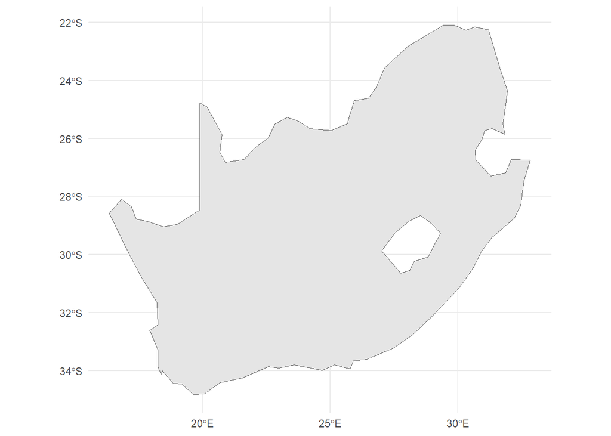

```r
world <- rnaturalearth::ne_countries(returnclass = "sf",scale = "small")

ggplot()+
  geom_sf(data = world%>%filter(name == "South Africa"))+
  theme_minimal()
```

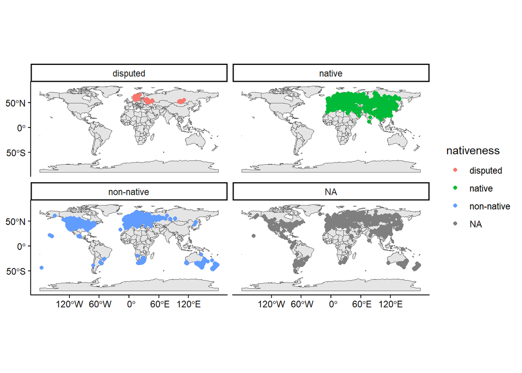

```r
ggplot(dat_geo)+
  geom_sf(data = world)+
  geom_sf(aes(colour = nativeness))+
  facet_wrap(~nativeness)
```

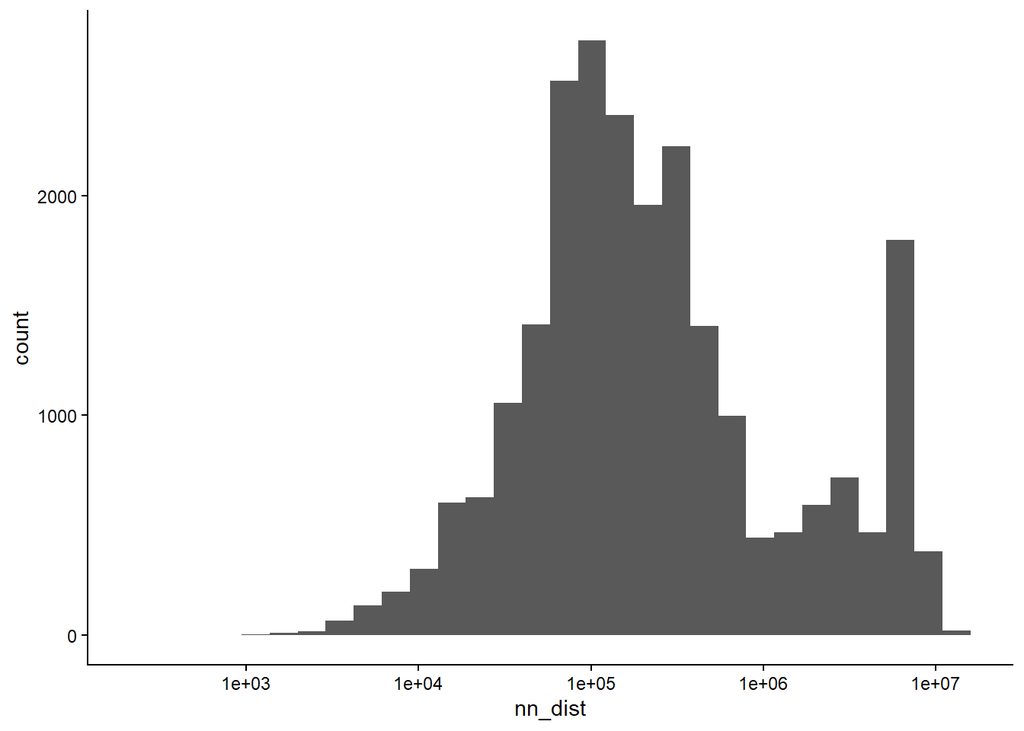

```r
dat%>%
  ggplot()+
  geom_histogram(aes(nn_dist))+
  scale_x_log10()
```

```r
dist<-2000000 # 2 000 km

dat_nn<-
  dat%>%
  mutate(nativeness = case_when(is.na(nativeness) & nn_dist < dist ~ nn_nativeness,
                                is.na(nativeness) & nn_dist > dist ~ "non-native",
                                TRUE ~ nativeness))
```

Let’s look at an example *C. horizontalis*. In the map below you can see the main problem. When you cross-reference the GBIF data with GloNAF and the WCVP you get the following map. As you can see, we are able to successfully assign a lot of records as native and non-native. However, there are also a lot of NA’s where neither GloNAF of the WCVP gives any information.

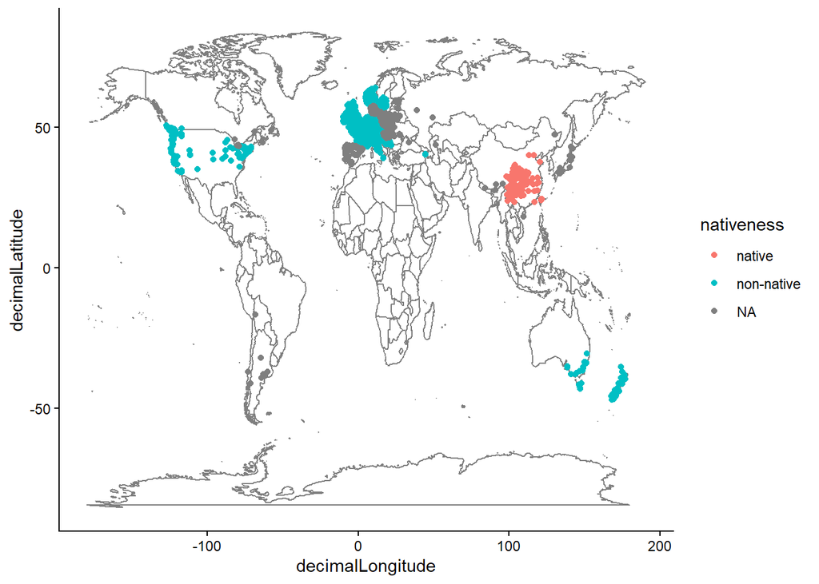

```r
dat%>%
  filter(wcvp_accepted_name == "Cotoneaster horizontalis")%>%
  ggplot()+
  annotation_borders()+
  geom_point(aes(decimalLongitude,decimalLatitude,colour = nativeness))
```

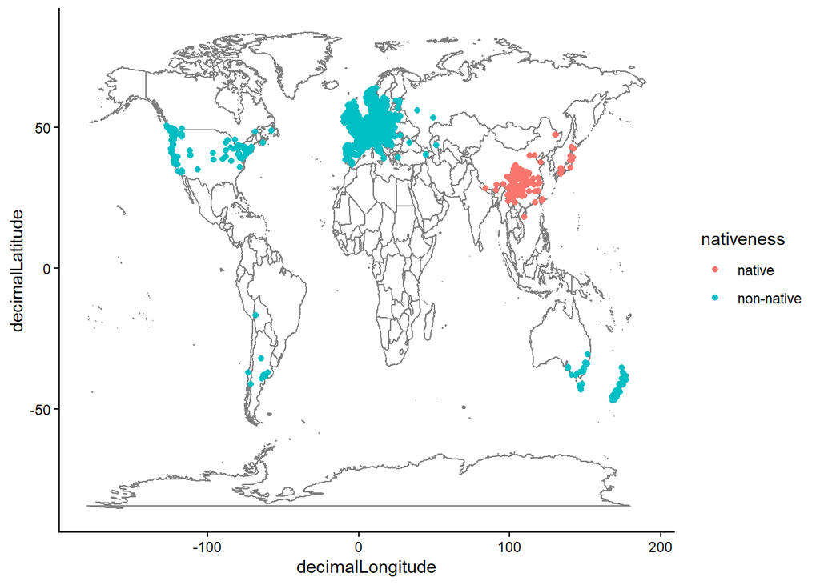

```r
dat_nn%>%
  filter(wcvp_accepted_name == "Cotoneaster horizontalis")%>%
  ggplot()+
  annotation_borders()+
  geom_point(aes(decimalLongitude,decimalLatitude,colour = nativeness))
```

```r
# one_degree_grid<-
#   sf::st_make_grid(dat_geo,cellsize = c(1,1))
```

Here you can see what I’ve been working on for the polygons, the idea was to cluster the records spatially and then calculate a convex/concave polygon for each group. The first problem with this was the spatial bias but this can be reduced using spatial thinning. The actual polygons overlap with the oceans so naturally they will have to be masked by a coastline layer.

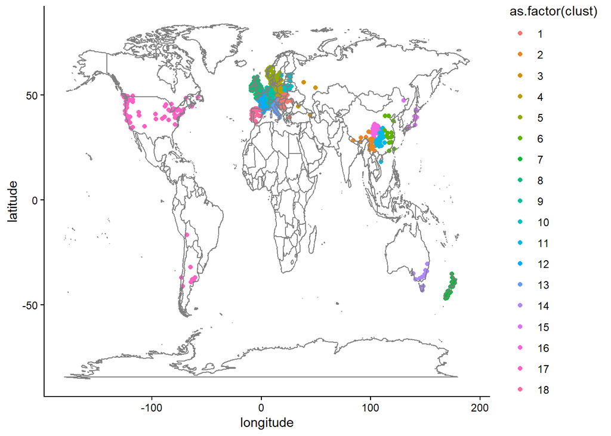

```r
dat_C.hor<-dat%>%
  filter(wcvp_accepted_name == "Cotoneaster horizontalis")%>%
  select(decimalLongitude,decimalLatitude)%>%
  rename(longitude = decimalLongitude,
         latitude = decimalLatitude)%>%
  as.matrix()


C.hor_thinned<-GeoThinneR::distance_thinning(dat_C.hor,thin_dist = 100)

# cbind(dat_C.hor,C.hor_thinned[[1]])%>%
#   as.data.frame()%>%
#   ggplot()+
#   geom_point(aes(longitude,latitude,colour = as.factor(V3)))



# dat_thinned<-
#   dat%>%
#   group_by(wcvp_accepted_name)%>%
#   group_modify(~{
#
#     coords <-   .x %>%
#       select(decimalLongitude,decimalLatitude)%>%
#       rename(longitude = decimalLongitude,
#              latitude = decimalLatitude)%>%
#       as.matrix()
#
#     thin_list <- GeoThinneR::distance_thinning(coords,thin_dist = 10,trials = 1)
#
#     cbind(., thinned = thin_list[[1]])
#   })
#
#
# dat_thinned%>%
#   filter(wcvp_accepted_name == "Cotoneaster horizontalis")%>%
#     select(decimalLongitude,decimalLatitude)%>%
#   rename(longitude = decimalLongitude,
#          latitude = decimalLatitude)%>%
#   as.matrix()%>%
#   kmeans(centers = 10)


test_thinned<-dat_C.hor%>%
  cbind(thinned = C.hor_thinned[[1]])%>%
  as.data.frame()%>%
  filter(thinned == 1)

cluster<-kmeans(test_thinned,centers = 18)


test_thinned%>%
  cbind(clust = cluster$cluster)%>%
  as.data.frame()%>%
  ggplot()+
  geom_point(aes(longitude,latitude,colour = as.factor(clust)))+
  annotation_borders()
```

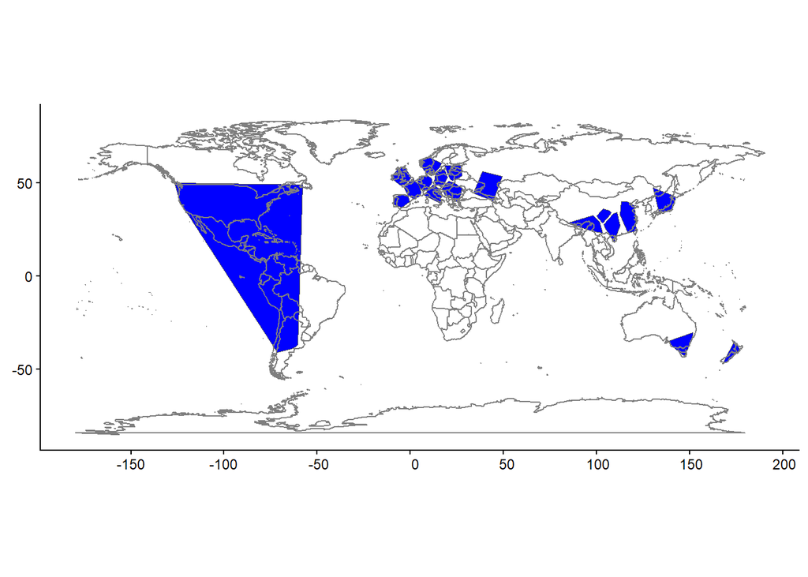

```r
test_thinned%>%
  cbind(clust = cluster$cluster)%>%
  as.data.frame()%>%
  st_as_sf(coords = c("longitude","latitude"))%>%
  group_by(clust) %>%
  summarise(geometry = st_union(geometry)) %>%
  st_convex_hull() %>%
  ggplot()+
  geom_sf(fill = "blue")+
  annotation_borders()
```

```r
# country_shapefiles%>%
#   left_join(glonaf_taxon_x_region%>%
#               group_by(status,tdwg3,taxa_accepted)%>%
#               summarise(obs = length(status))%>%
#               group_by(tdwg3,taxa_accepted)%>%
#               filter(!(status == "Naturalized" & "Invasive" %in% status))%>%
#               rename(wcvp_accepted_name = taxa_accepted)%>%
#               ungroup())%>%
#   left_join(wcvp_native%>%
#               mutate(plant_name_id_stand = accepted_plant_name_id,
#                      tdwg3 = area_code_l3)%>%
#               select(plant_name_id_stand,tdwg3,introduced)%>%
#               filter(!is.na(tdwg3))%>%
#               unique())%>%view()



glonaf_status_sf<-
  glonaf_taxon_x_region%>%select(taxon_wcvp_id,
                                 status,
                                 taxa_accepted,
                                 code,
                                 name,
                                 tdwg3)%>%
  mutate(status = "non_native",
         LEVEL3_COD = tdwg3)%>%
  left_join(translation_table%>%
              mutate(taxa_accepted = taxon_stand))
wcvp_status_sf<-
  wcvp_native%>%
  select(plant_name_id,
         area_code_l3,
         introduced)%>%
  mutate(status = case_when(introduced == 1 ~ "non-native",
                            introduced == 0 ~ "native"))%>%
  mutate(LEVEL3_COD = area_code_l3)%>%
  left_join(translation_table%>%
              mutate(plant_name_id = plant_name_id_stand))
country_joined<-
  full_join(
    country_shapefiles,
    left_join(wcvp_status_sf,glonaf_status_sf)
  )
```

[output not shown]

Here is another visualisation of the same problem outlined above, for *C. horizontalis*. Many records are inside the polygons but there are also many records outside and nearby the polygons.

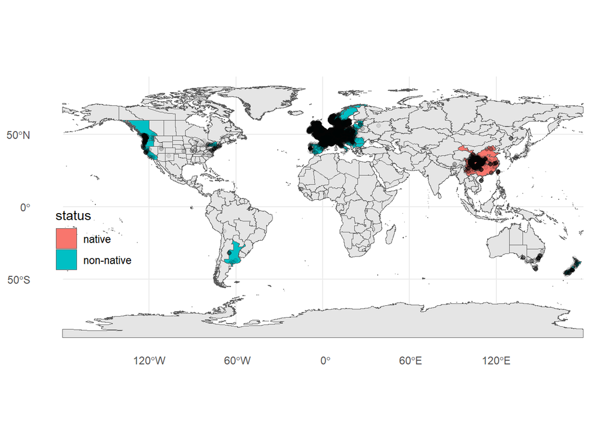

```r
country_joined%>%
  filter(wcvp_accepted_name == "Cotoneaster horizontalis")%>%
  ggplot()+
  geom_sf(data = country_shapefiles)+
  geom_sf(aes(fill = status))+

  geom_sf(data = gbif_geo%>%filter(species == "Cotoneaster horizontalis"),
         alpha = 0.1)+
  theme_minimal()+

  theme(legend.position = "inside",
        legend.position.inside = c(0.1,0.4)
        )
```